# JABBA3 user guide

## 19.2 EB/SB curves from length selectivity

With the Selex model (`jb3_model(ebsb = )`) the state is spawning biomass and the indices and removals are mapped through the equilibrium ratio of exploitable to spawning biomass, EB/SB, as a function of SB/SB0. `jb3_selex()` computes this curve for each fleet from `lhpar` and length-based selectivity, over a grid of F with Beverton-Holt recruitment, and fits the saturating curve $c(u_1, u_2, u_3, P_1, P_2)$. Selectivity parameters use the FLicc names and functions (logistic: `SL50`, `SL95`; `dsnormal`: `mode`, `lsd`, `rsd`; `normal`; `binormal`; `bidsnormal`), here as an `FLPars` as returned by `FLicc::selpars_flicc(fit)`; selectivity at length is converted to age by integrating over the length-at-age distribution (`CVL = 0.1`). Curves are fitted to the equilibrium over SB/SB0 = 0.1–0.9 (`fit.range`, as JABBA-Select) and extend smoothly to the state bounds (`P.lim = c(0.02, 1.3)`), so that the likelihood has no kink where the states may lie.

```r
selpar <- FLPars(Gillnet = FLPar(mode = 32, lsd = 4, rsd = 15),
                 Longline = FLPar(SL50 = 28, SL95 = 36))
sx <- jb3_selex(lh2, selpar)
sx
```

```
#> JABBA3 Selex inputs: 2 selectivity curve(s); sexes F, M ; steepness 0.75
#>   Leslie r = 0.151, generation time = 18.0 years
#>             u1     u2    u3   P1  P2   units
#> Gillnet  1.386 0.9287 2.323 0.02 1.3 biomass
#> Longline 1.268 1.0850 3.026 0.02 1.3 biomass
#>   pass the object to jb3_model(ebsb = ); with several curves set ebsb.index and ebsb.catch
```

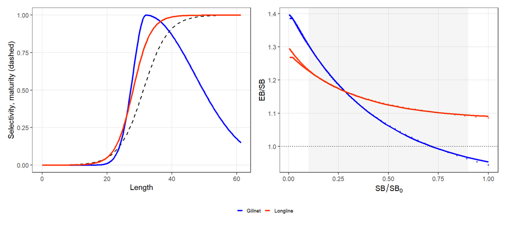

```r
jbplot_selex(sx)
```

The JABBA 5-parameter selectivity (JABBA-Select; `jb3_sel5()`: `SL50`, `SL95`, then a descending limb from `SLdesc` with coefficient of variation `CVdesc` towards a minimum `Smin`) can be used at length, alongside the FLicc functions:

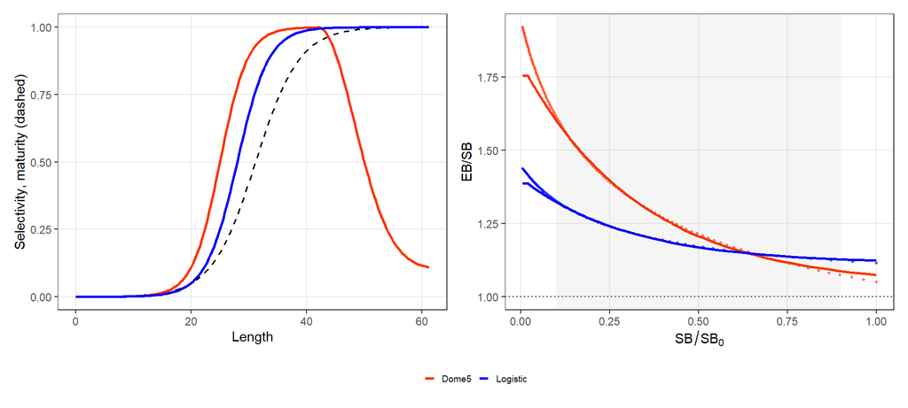

```r
sx5 <- jb3_selex(lhpar, list(Logistic = c(SL50 = 28, SL95 = 36),
                             Dome5 = c(SL50 = 25, SL95 = 32, SLdesc = 42, CVdesc = 0.15, Smin = 0.1)))
jbplot_selex(sx5)
```

or at age (`sel.type = "age"`; parameters in years):

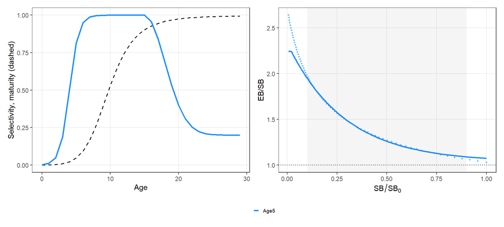

```r
sxa <- jb3_selex(lhpar, list(Age5 = c(SL50 = 4, SL95 = 6, SLdesc = 15, CVdesc = 0.2, Smin = 0.2)),
                 sel.type = "age")
jbplot_selex(sxa, at = "age")
```

## 19.3 Example: a change in selectivity (KOBsim)

`kobsim` is the simulated silver kob data set of the JABBA-Select example (Winker et al. 2020): an age-structured operating model run for 40 years, in which the minimum size limit was raised in year 26 (length at 50% selectivity 300 → 500 mm). Both indices are split at the change (`A1.S1`, `A1.S2`, `A2.S1`, `A2.S2`) and share one catchability per index, so that the jump in exploitable biomass relative to spawning biomass is carried by the EB/SB curves rather than by a new catchability. The removal curve changes with the selectivity (`ebsb.catch` by year; reference points and projections use the curve of the last year).

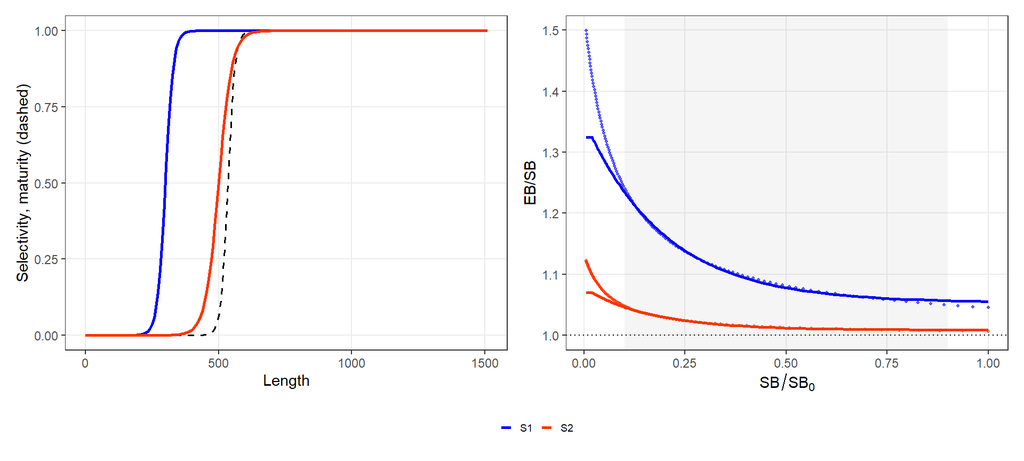

```r
data(kobsim)
sxk <- jb3_selex(kobsim$lhpar, kobsim$selpar)                   # EB/SB curves for S1 and S2
jbplot_selex(sxk)
```

**The r prior from the age-structured equilibrium.** $r_{Leslie}/2$ ignores selectivity and the stock-recruitment curve beyond its slope (Chapter 5b). `jb3_asem_prior()` generates the r prior as the ASEM prior of JABBA-Select: a Monte Carlo over M and steepness through the age-structured equilibrium with the fishery’s selectivity gives, for each draw, $F_{MSY}$, the harvest rate at MSY and the production-function shape. The harvest rate that r must match depends on the model:

- standard JABBA3 (`state = "EB"`): $K = EB_0$, $B_{MSY}/K = EB_{MSY}/EB_0$ and $r = m\,MSY/EB_{MSY}$;
- Selex (`state = "SB"`) with catch removed through the EB/SB curve (the default, `ebsb.removal = TRUE`): $K = SB_0$, $B_{MSY}/K = SB_{MSY}/SB_0$ and $r = m\,MSY/EB_{MSY}$;
- Selex with catch removed from SB directly (`ebsb.removal = FALSE`, as JABBA-Select v1; `removal = "SB"`): $r = m\,MSY/SB_{MSY}$.

Here with the current selectivity (`catch = "S2"`):

```r
prk <- jb3_asem_prior(kobsim$lhpar, kobsim$selpar, catch = "S2", M.cv = 0.25, h.sd = 0.08, nsim = 300)
prk
```

```
#> JABBA3 ASEM productivity prior (300 draws; state SB, catch removed from EB)
#>   F_MSY 0.155 | H_MSY 0.132 | B_MSY/K 0.308 (m = 0.716)
#>   r prior (shape fixed at the median): median 0.095, log.sd 0.264
#>   for comparison: r_Leslie/2 converted to this shape = 0.096
#>   use: jb3_model(BmsyK = $BmsyK), jb3_priors(r = $r)
```

The r prior is conditional on the shape fixed at the median $B_{MSY}/K$ (`jb3_model(BmsyK = prk$BmsyK)`). To estimate the shape, `prk$m` can be used as the m prior (independent of r in JABBA3; JABBA-Select v1 used the correlated prior `prk$lmvn` on $\log(H_{MSY}, m)$).

```r
dk  <- jb3_data(kobsim$catch, kobsim$cpue, kobsim$se, stock = "kobsim")
eck <- ifelse(dk$years < kobsim$sel.change, "S1", "S2")         # removal curve by year
mk  <- jb3_model(BmsyK = prk$BmsyK, sets.q = c(1, 1, 2, 2), ebsb = sxk,
                 ebsb.index = c("S1", "S2", "S1", "S2"), ebsb.catch = eck)
fk  <- jabba3(dk, jb3_priors(dk, r = prk$r, K = c(8*max(dk$catch), 1)), mk, osa = FALSE)
```

The fit with `jabbaplot3()` (here without the biomass trigger and limit lines):

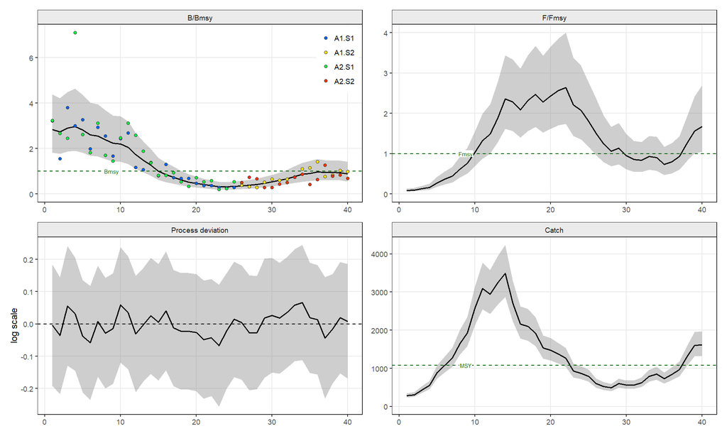

```r
jabbaplot3(fk, bthr = NULL, blim = NULL, panels = c("B/Bmsy", "F/Fmsy", "procdev", "Catch"))
```

The estimated spawning-biomass depletion against the operating-model truth:

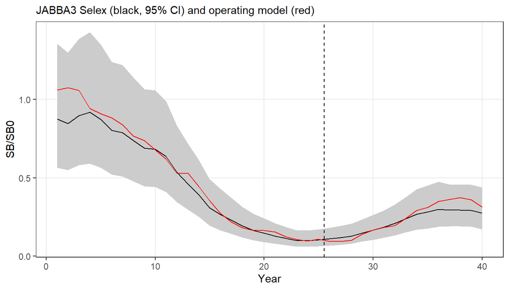

```r
bkk <- fk$ts[fk$ts$quantity == "B/K", ]
ggplot2::ggplot(bkk, ggplot2::aes(year, est)) +
  ggplot2::geom_ribbon(ggplot2::aes(ymin = lci, ymax = uci), fill = "grey80") + ggplot2::geom_line() +
  ggplot2::geom_line(data = data.frame(year = kobsim$truth$year, est = kobsim$truth$SB/kobsim$SB0), colour = "red") +
  ggplot2::geom_vline(xintercept = kobsim$sel.change - 0.5, linetype = 2) +
  ggplot2::labs(x = "Year", y = "SB/SB0", subtitle = "JABBA3 Selex (black, 95% CI) and operating model (red)") + theme_jabba3()
```

## 19.4 Example: an index in numbers (bigeye)

Many indices, in particular tuna longline CPUE, are in numbers. Because fishing shifts the exploitable stock towards smaller fish, exploitable numbers per unit SB rise more steeply with depletion than exploitable biomass, so an index in numbers declines less than one in weight, even when selectivity equals maturity and the EB/SB curve is flat. Mapped with the weight curve, the model reads this as less depletion and becomes optimistic. `jb3_selex(units = "numbers")` gives the curve of exploitable numbers to SB (EN/SB; `I.unit = 0` in JABBA-Select). A fleet with catch in weight and an index in numbers needs both curves from the same selectivity: the index is mapped with the numbers curve (`ebsb.index`) and the catch with the weight curve (`ebsb.catch`).

The bigeye indices are the 2018 joint longline index, standardised as catch in number per hook (Hoyle et al. 2019). Like JABBA in the 2018 assessment, the other examples in this guide treat them as an index of exploitable biomass. The biology below is approximate (von Bertalanffy growth instead of the Richards curve of the 2018 assessment, M = 0.35 at all ages, maturity at age 3, steepness 0.8), and the longline selectivity is illustrative, so the example contrasts the two units rather than providing an assessment:

```r
Lb  <- function(a) 217.3*(1 - exp(-0.18*(a + 0.709)))
lhb <- c(linf = 217.3, k = 0.18, t0 = -0.709, a = 2.396e-5, b = 2.9774, M = 0.35, s = 0.8,
         L50 = (Lb(2) + Lb(3))/2, L95 = Lb(3), amax = 15)
llb <- c(SL50 = 100, SL95 = 125)                                  # illustrative longline selectivity (cm)
sxb <- jb3_selex(lhb, list(LL = llb, LL.N = llb), units = c("biomass", "numbers"))
sxb
```

```
#> JABBA3 Selex inputs: 2 selectivity curve(s); sex F ; steepness 0.8
#>   Leslie r = 0.427, generation time = 7.1 years
#>           u1     u2    u3   P1  P2   units
#> LL   0.80550 0.9546 2.899 0.02 1.3 biomass
#> LL.N 0.03461 0.0152 3.191 0.02 1.3 numbers
#>   pass the object to jb3_model(ebsb = ); with several curves set ebsb.index and ebsb.catch
```

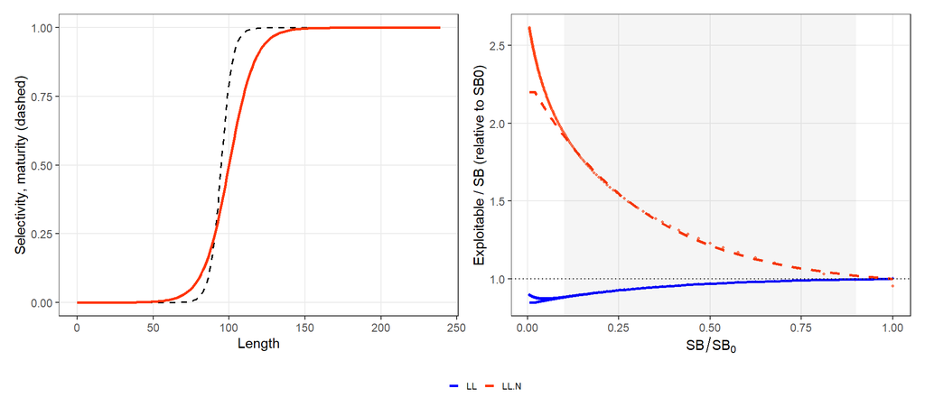

```r
jbplot_selex(sxb)
```

The same data fitted with standard JABBA3, and with Selex with the index mapped in weight and in numbers (r priors from the equilibrium for each model):

```r
prb  <- jb3_asem_prior(lhb, llb, M.cv = 0.2, h.sd = 0.08, nsim = 300)
prbE <- jb3_asem_prior(lhb, llb, state = "EB", M.cv = 0.2, h.sd = 0.08, nsim = 300)
db   <- jb3_data(bet$catch, bet$cpue, bet$se, stock = "bet")
Kb   <- c(8*max(db$catch), 1)
fb <- list(
  standard        = jabba3(db, jb3_priors(db, r = prbE$r, K = Kb), jb3_model(BmsyK = prbE$BmsyK), osa = FALSE),
  selex.weight    = jabba3(db, jb3_priors(db, r = prb$r, K = Kb),
                           jb3_model(BmsyK = prb$BmsyK, ebsb = sxb, ebsb.index = "LL", ebsb.catch = "LL"), osa = FALSE),
  selex.numbers   = jabba3(db, jb3_priors(db, r = prb$r, K = Kb),
                           jb3_model(BmsyK = prb$BmsyK, ebsb = sxb, ebsb.index = "LL.N", ebsb.catch = "LL"), osa = FALSE))
t(sapply(fb, function(f){ s <- f$ts[f$ts$year == max(f$years) & f$ts$quantity %in% c("B/Bmsy", "F/Fmsy"), ]
  stats::setNames(round(s$est, 2), s$quantity) }))
```

```
#>               B/Bmsy F/Fmsy
#> standard        1.01   0.92
#> selex.weight    1.03   0.90
#> selex.numbers   0.68   1.33
```

Selectivity is close to maturity here, so the weight curve is nearly flat and the Selex fit with the index in weight is close to standard JABBA3. Read as numbers, however, the index declines less than the biomass, so mapping it as numbers implies a more depleted stock (lower B/B<sub>MSY</sub>, higher F/F<sub>MSY</sub>). The 2018 assessment combined across models gave B/B<sub>MSY</sub> = 0.59–0.82 and F/F<sub>MSY</sub> = 1.21–1.63 for 2017 (ICCAT 2018).

> Check that the selectivity is plausible against the length compositions (e.g. with an FLicc fit) before using the curve: it determines how the exploitable-biomass indices map onto the spawning-biomass state.

# 20 From SPiCT: North Sea thornback ray

Thornback ray (*Raja clavata*) in Subarea 4 and divisions 3.a and 7.d (North Sea, Skagerrak, Kattegat and eastern English Channel; rjc.27.3a47d) was benchmarked at the ICES workshop WKBELASMO with SPiCT (ICES, 2023; Pedersen and Berg, 2017). This chapter converts the final SPiCT assessment to JABBA3, introduces the hybrid F random walk that JABBA3 uses for index years without catch, adds the production lag and AR(1) process error, compares the result with the SPiCT assessment, and derives the ICES catch advice.

## 20.1 The benchmark assessment

The final assessment of WKBELASMO 2023 had:

| Setting | Final SPiCT assessment |
| --- | --- |
| Removals | 1999–2021 (landings and dead discards; 1999–2008 reconstructed), with twice the catch SD before 2009 (`stdevfacC = 2`) |
| Index 1 (Q14) | NS-IBTS-Q1 and FR-CGFS-Q4 combined, biomass of rays ≥ 30 cm, 1989–2021 |
| Index 2 (Q3) | NS-IBTS-Q3, BTS-Eng-Q3 and BTS-BEL-Q3 combined, biomass ≥ 30 cm, 1991–2021 |
| r prior | 0.15 (CV 0.3) |
| Shape | Schaefer (n = 2) |
| Initial depletion | bkfrac 0.15 (CV 0.5) |
| Process error | sdb 0.07 (CV 0.5) |
| Time step | `dteuler = 1/4` |

`data(rjc)` holds the SPiCT input list of the final assessment (`inp`), the SPiCT fit as an `FLStockR` (`spict.stk`, from `FLRef::spict2FLStockR(base, rel = TRUE)`) and the life-history parameters of the benchmark (`info`):

```r
data(rjc)
str(rjc$inp, max.level = 1)
```

```
#> List of 8
#>  $ timeC    : int [1:23] 1999 2000 2001 2002 2003 2004 2005 2006 2007 2008 ...
#>  $ obsC     : num [1:23] 1705 2012 2133 2142 2134 ...
#>  $ stdevfacC: num [1:23] 2 2 2 2 2 2 2 2 2 2 ...
#>  $ timeI    :List of 2
#>  $ obsI     :List of 2
#>  $ stdevfacI:List of 2
#>  $ dteuler  : num 0.25
#>  $ priors   :List of 6
```

```r
rjc$info$lh
```

```
#>     Linf        k       t0      L50      L95        a
#> 123.6200   0.1290  -1.1540  73.7000  82.0000   0.0045
#>        b        M     amax
#>   3.0961   0.1880  17.0000
```

With the spict package installed, the assessment refits with `spict::fit.spict(rjc$inp)`.

## 20.2 Conversion

```r
xs <- spictinp2jabba3(rjc$inp, stock = "rjc.27.3a47d")
xs$priors
```

```
#> JABBA3 priors (lognormal: median, log.sd; on = 1)
#>         median log.sd on
#> r       0.1430  0.300  1
#> K           NA  0.833  0
#> bkinit  0.1320  0.500  1
#> sdb     0.0618  0.500  1
#> m       2.0000  0.001  1
#> sdi.Q14 0.2690  0.200  1
#> sdi.Q3  0.3120  0.200  1
#> sdb: user lognormal
#> q: flat on log q
#> kdyn (dynamic sdb only): normal(0.37, 0.15)
```

The indices start ten years before the catch, so the model years are 1989–2021 as in SPiCT; the catch in 1989–1998 is estimated (next section). The index observation SD is SPiCT’s `sdi[index] * stdevfacI`, with one sdi prior per index, and the catch SD is `sdc * stdevfacC` (0.2 before 2009, 0.1 after). The annual model refers the indices to the start of the year; SPiCT uses the survey timing within the year (Q3 at 0.7).

```r
fr <- jabba3(xs$data, xs$priors, xs$model, run = "JABBA3")
fr$pars[c("K", "r", "bkinit", "sdb", "sdi1", "sdi2", "sdf"), c("est", "lci", "uci")]
```

```
#>                 est          lci          uci
#> K      2.283124e+05 6.776159e+04 7.692642e+05
#> r      1.907504e-01 1.230691e-01 2.956527e-01
#> bkinit 1.179601e-01 5.427263e-02 2.563832e-01
#> sdb    5.186014e-02 2.149269e-02 1.251344e-01
#> sdi1   2.776281e-01 2.213547e-01 3.482075e-01
#> sdi2   3.044796e-01 2.401115e-01 3.861034e-01
#> sdf    2.901650e-01 1.256643e-01 6.700051e-01
```

## 20.3 Special feature: the hybrid F random walk

JABBA3 is conditioned on catch: the catch of each year enters the biomass equation, with lognormal catch error when `catch.error = TRUE`. SPiCT instead models fishing mortality as a random walk in all years and treats the catch as an observation of it. JABBA3 combines the two when the catch series has gaps or is shorter than the indices (`jb3_data(catch.gaps = "estimate")`, set here by the converter):

- **Years with catch** stay catch-conditioned, as before.
- **Years without catch** get a harvest rate $H_t$ as a random effect, and the catch follows from it: $\hat{C}_t = H_t K P_t$.
- **The random walk** links the harvest rates on the log scale, $\log H_t \sim N(\log H_{t-1}, \sigma_F^2)$, for every step that involves a year without catch. The walk is therefore anchored to the harvest rate implied by the first observed catch (1999 here, $H = C/(K P)$), and the index information on biomass in 1989–1998 informs the catch in those years.
- $\sigma_F$ has the prior `jb3_priors(sdf = )` (median 0.3, log-SD 0.5 by default; a SPiCT `logsdf` prior is carried over).
- With `jb3_model(frw.all = TRUE)` the random walk applies to all years (SPiCT-like). $\sigma_F$ is then also informed by the years with catch, which tends to shrink it and to smooth F through the gaps.

`jbplot_catcherror()` shows the observed catch (1999–2021) against the estimated catch over all model years. The years without catch are shaded: the catch there is predicted from the random walk and the biomass, and its uncertainty narrows towards the first observed catch.

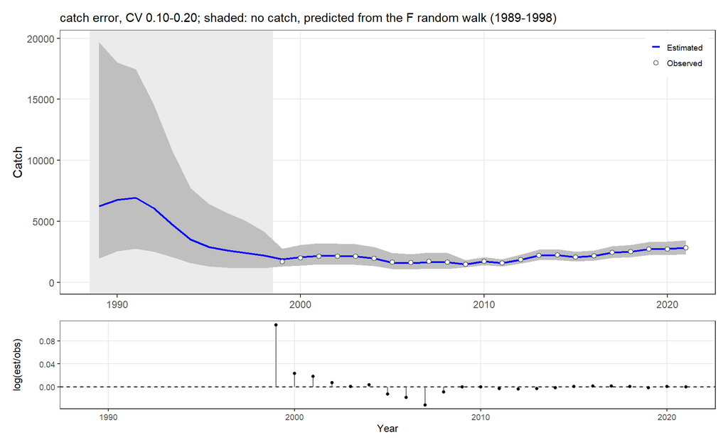

```r
jbplot_catcherror(fr)
```

## 20.4 Alternative runs: F random walk, lag and AR(1)

Two alternatives to the converted run: the random walk on F in all years (SPiCT-like), and the protocol for process error of JABBA3, a production lag at the age at maturity with AR(1) process deviations. Age at maturity follows from the benchmark growth parameters and the length at 50% maturity (73.7 cm), and the AR(1) persistence is the default $\rho = 0.75$:

```r
fa <- update(fr, model = list(frw.all = TRUE), run = "F random walk (all years)")
lh <- rjc$info$lh
amat <- round(lh[["t0"]] - log(1 - lh[["L50"]]/lh[["Linf"]])/lh[["k"]])
amat
```

```
#> [1] 6
```

```r
fl <- update(fr, model = list(lag = amat, rho = 0.75), run = "Lag 6 + AR(1)")
```

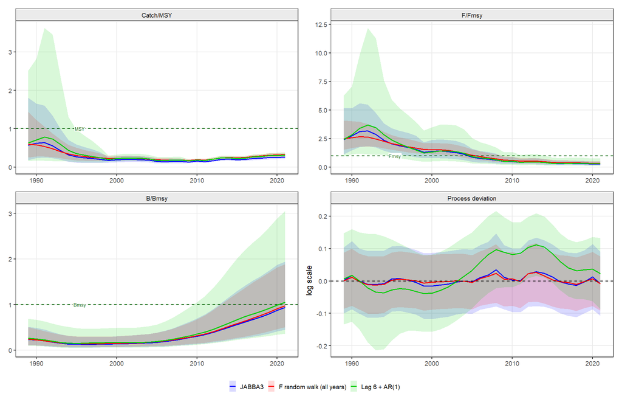

```r
jabbaplot3(list(JABBA3 = fr, `F random walk (all years)` = fa, `Lag 6 + AR(1)` = fl),
           bthr = NULL, blim = NULL, panels = c("Catch", "F/Fmsy", "B/Bmsy", "procdev"))
```

Terminal status (2021) of the three runs:

```r
st <- function(f){ x <- f$ts[f$ts$year == 2021 & f$ts$quantity %in% c("B/Bmsy", "F/Fmsy"), ]
  stats::setNames(sprintf("%.2f (%.2f-%.2f)", x$est, x$lci, x$uci), x$quantity) }
noquote(t(sapply(list(JABBA3 = fr, `F random walk (all years)` = fa, `Lag 6 + AR(1)` = fl), st)))
```

```
#>                           B/Bmsy
#> JABBA3                    0.94 (0.45-1.94)
#> F random walk (all years) 0.98 (0.51-1.88)
#> Lag 6 + AR(1)             1.05 (0.36-3.05)
#>                           F/Fmsy
#> JABBA3                    0.28 (0.16-0.47)
#> F random walk (all years) 0.34 (0.22-0.51)
#> Lag 6 + AR(1)             0.30 (0.12-0.75)
```

The converted run reproduces the SPiCT perception: depleted in the 1990s, F below $F_{MSY}$ since the mid-2000s and a rebuilding stock close to $B_{MSY}$ in 2021 ($B/B_{MSY}$ 1.03 in SPiCT at the start of 2021). It is slightly lower in both $B/B_{MSY}$ and $F/F_{MSY}$, mainly because of the annual time step and the index timing. The random walk on all years changes little. With the lag and AR(1) process error, the process deviations become persistent (below average production in the 1990s, above average from the mid-2000s, when the stock rebuilt), status is slightly higher, and the intervals are wider: the persistence of the production anomalies shows as uncertainty.

## 20.5 Comparison with the SPiCT assessment

`jb3_FLStockR()` converts a JABBA3 fit to an `FLStockR` with posterior draws. `jbplot_advice()` takes `FLStock`/`FLStockR` objects as well as fits, so the lag + AR(1) run can be shown with the SPiCT assessment as an `FLStocks` (or a list mixing fits and stocks). The SPiCT `FLStockR` holds the estimated trajectory only, so the intervals are shown for JABBA3. The lag + AR(1) run follows the SPiCT $B/B_{MSY}$ trajectory closely:

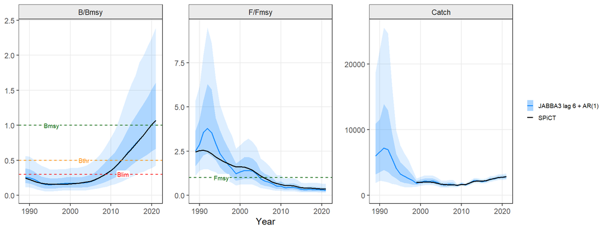

```r
stks <- FLCore::FLStocks(`JABBA3 lag 6 + AR(1)` = jb3_FLStockR(fl, ndraws = 1000), SPiCT = rjc$spict.stk)
jbplot_advice(stks, colours = c("dodgerblue", "black"), ncol = 3)
```

The same with `FLRef::plotAdvice()`, with the colours set manually:

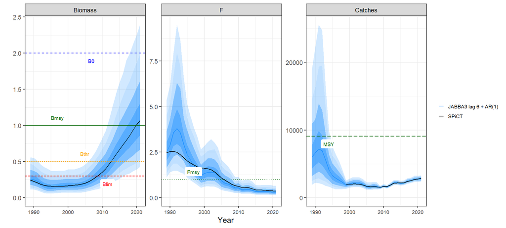

```r
FLRef::plotAdvice(stks, ncol = 3, type = "spm") +
  ggplot2::scale_fill_manual(values = c("dodgerblue", "black")) +
  ggplot2::scale_colour_manual(values = c("dodgerblue", "black"))
```

## 20.6 ICES catch advice: HCR and catch fractiles

ICES advice for stocks assessed with surplus production models follows a fixed routine (as for SPiCT stocks; the WKBELASMO forecast used it with SPiCT). `jb3_advice()` runs it in one call:

[output not shown]

The assessment of 2022 uses data up to 2021, so there is one intermediate year (2022) before the advice year (2023). Other catch options, such as the status quo catch and a 20% increase (two of the WKBELASMO scenarios), are added with `catch`. The advice is derived for the converted run and for the lag + AR(1) run:

```r
csq <- mean(tail(fr$data$catch, 2))          # average removals 2020-2021
opts <- c(`Status quo catch` = csq, `Status quo catch +20%` = 1.2*csq)
adv0 <- jb3_advice(fr, fractiles = c(0.35, 0.25, 0.15), imp.years = 1, catch = opts, ndraws = 4000)
adv  <- jb3_advice(fl, fractiles = c(0.35, 0.25, 0.15), imp.years = 1, catch = opts, ndraws = 4000)
adv
```

```
#> Catch advice for 2023 (assessment to 2021), MSY hockey-stick rule: F = 1.00 Fmsy x min(1, B/0.50 Bmsy)
#> Intermediate year 2022: status quo F (median catch 3135)
#> Advice-year catch under the HCR: median 10521; 35th percentile: 8847; 25th percentile: 7594; 15th percentile: 6238
#>
#>                  Basis C 2023 F/Ftgt 2023 B/Btgt 2024
#>            HCR, median  10521       0.993       1.157
#>   HCR, 35th percentile   8847       0.835       1.175
#>   HCR, 25th percentile   7594       0.716       1.188
#>   HCR, 15th percentile   6238       0.589       1.202
#>       Status quo catch   2783       0.263       1.242
#>  Status quo catch +20%   3340       0.315       1.235
#>  B change P(B>Blim) P(B>Bpa) P(B>Btgt) P(B<Blim)
#>       3.6      99.2     93.8      60.2       0.8
#>       5.2      99.2     94.3      61.1       0.8
#>       6.4      99.3     94.5      62.1       0.7
#>       7.7      99.3     94.8      62.9       0.7
#>      11.2      99.4     95.4      65.3       0.6
#>      10.6      99.4     95.4      64.9       0.6
#>  PA (P(B<Blim) <= 5%)
#>                   yes
#>                   yes
#>                   yes
#>                   yes
#>                   yes
#>                   yes
```

The two runs side by side:

```r
cmp <- function(a, f){
  tb <- a$table; r <- function(b) tb[tb$Basis == b, ]
  fmt <- function(b) sprintf("%s (F/Fmsy %.2f)", format(round(r(b)[[2]]), big.mark = ","), r(b)[[3]])
  c(`B/Bmsy 2021` = sprintf("%.2f", f$ts$est[f$ts$quantity == "B/Bmsy" & f$ts$year == 2021]),
    MSY = format(round(f$refpts["MSY", "est"]), big.mark = ","),
    `CV of the 2023 catch under the HCR` = sprintf("%.2f", stats::sd(log(a$catch))),
    `Median catch 2023` = format(round(stats::median(a$catch)), big.mark = ","),
    `35th percentile (ICES advice)` = fmt("HCR, 35th percentile"),
    `25th percentile` = fmt("HCR, 25th percentile"),
    `15th percentile` = fmt("HCR, 15th percentile"),
    `P(B 2024 < Blim) at the 35th` = sprintf("%.1f%%", r("HCR, 35th percentile")$`P(B<Blim)`))
}
knitr::kable(cbind(JABBA3 = cmp(adv0, fr), `Lag 6 + AR(1)` = cmp(adv, fl)))
```

|  | JABBA3 | Lag 6 + AR(1) |
| --- | --- | --- |
| B/Bmsy 2021 | 0.94 | 1.05 |
| MSY | 10,888 | 9,092 |
| CV of the 2023 catch under the HCR | 0.27 | 0.49 |
| Median catch 2023 | 11,450 | 10,521 |
| 35th percentile (ICES advice) | 10,330 (F/Fmsy 0.90) | 8,847 (F/Fmsy 0.83) |
| 25th percentile | 9,546 (F/Fmsy 0.83) | 7,594 (F/Fmsy 0.72) |
| 15th percentile | 8,632 (F/Fmsy 0.75) | 6,238 (F/Fmsy 0.59) |
| P(B 2024 < Blim) at the 35th | 0.1% | 0.8% |

For the lag + AR(1) run: the distribution of the advice-year catch under the HCR, with the median and the fractiles,

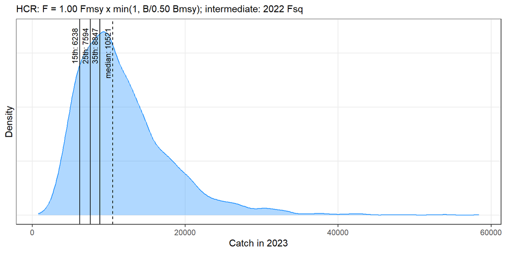

```r
jbplot_advicecatch(adv)
```

the forecast of the catch options (`adv$options`, a `jb3_fwd()` projection),

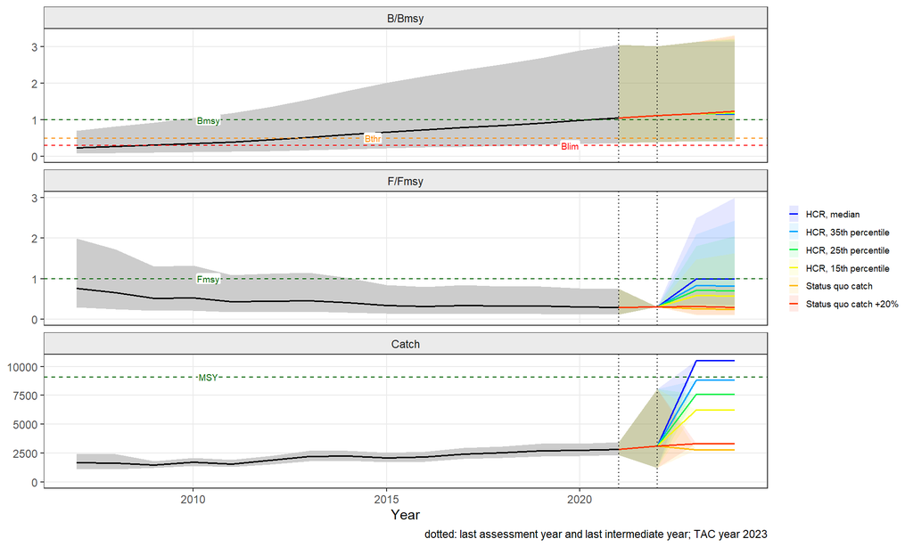

```r
jbplot_projection(adv$options, nyears = 15)
```

and the advice table (`adv$table`):

```r
knitr::kable(adv$table)
```

| Basis | C 2023 | F/Ftgt 2023 | B/Btgt 2024 | B change | P(B>Blim) | P(B>Bpa) | P(B>Btgt) | P(B<Blim) | PA (P(B<Blim) <= 5%) |
| --- | --- | --- | --- | --- | --- | --- | --- | --- | --- |
| HCR, median | 10521 | 0.993 | 1.157 | 3.6 | 99.2 | 93.8 | 60.2 | 0.8 | yes |
| HCR, 35th percentile | 8847 | 0.835 | 1.175 | 5.2 | 99.2 | 94.3 | 61.1 | 0.8 | yes |
| HCR, 25th percentile | 7594 | 0.716 | 1.188 | 6.4 | 99.3 | 94.5 | 62.1 | 0.7 | yes |
| HCR, 15th percentile | 6238 | 0.589 | 1.202 | 7.7 | 99.3 | 94.8 | 62.9 | 0.7 | yes |
| Status quo catch | 2783 | 0.263 | 1.242 | 11.2 | 99.4 | 95.4 | 65.3 | 0.6 | yes |
| Status quo catch +20% | 3340 | 0.315 | 1.235 | 10.6 | 99.4 | 95.4 | 64.9 | 0.6 | yes |

# 21 FLR outputs

`jb3_flqs()` returns the time series as `FLQuants` (`stock` = B/Bmsy, `harvest` = F/Fmsy, `biomass`, `F` and `catch`), with the draws as iterations when the fit has draws; `jb3_flpar()` returns parameters, reference points and current status as an `FLPar`.

```r
fq <- jb3_flqs(fit)
names(fq)
```

```
#> [1] "stock"   "harvest" "biomass" "F"       "catch"
```

```r
dim(fq$stock)
```

```
#> [1]    1   68    1    1    1 1000
```

```r
jb3_flpar(fit)
```

```
#> An object of class "FLPar"
#> params
#>        K        r        m     Bmsy     Fmsy      MSY
#> 1.17e+06 1.93e-01 1.00e+00 4.32e+05 1.93e-01 8.33e+04
#>    BmsyK      sdb   B.Bmsy   F.Fmsy
#> 3.68e-01 9.45e-02 7.97e-01 1.16e+00
#> units:  NA NA NA NA NA NA NA NA NA NA
```

These plot with ggplotFL and can be used in FLR workflows (e.g. as the output of an estimator in `mse`):

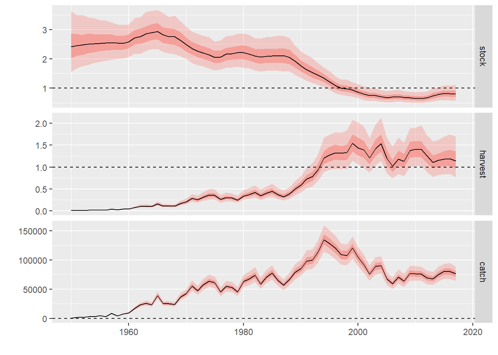

```r
library(ggplotFL)
plot(fq[c("stock", "harvest", "catch")]) + ggplot2::geom_hline(yintercept = 1, linetype = 2)
```

## 21.1 FLStockR

`jb3_FLStockR()` converts the fit to a biomass-dynamic `FLStockR`, as `FLRef::jabba2FLStockR()`: biomass in `stock` (and `ssb()`), catch, and the harvest rate in `harvest`, with the draws as iterations. The `refpts` slot holds $F_{MSY}$, $B_{MSY}$, MSY, $B_{thr}$ and $B_{lim}$ (by default 0.5 and 0.3 $B_{MSY}$, the SPiCT benchmark defaults) and $B_0$. Advice from surplus production models is given in relative terms, so by default the stock is in $B/B_{MSY}$ and $F/F_{MSY}$; `rel = FALSE` gives absolute biomass and harvest rate.

```r
stk <- jb3_FLStockR(fit, ndraws = 500)        # relative (B/Bmsy, F/Fmsy) by default
stk@refpts
```

```
#> An object of class "FLPar"
#> params
#>     Fmsy     Bmsy      MSY     Bthr     Blim       B0
#>     1.00     1.00 83335.26     0.50     0.30     2.72
#> units:  NA
```

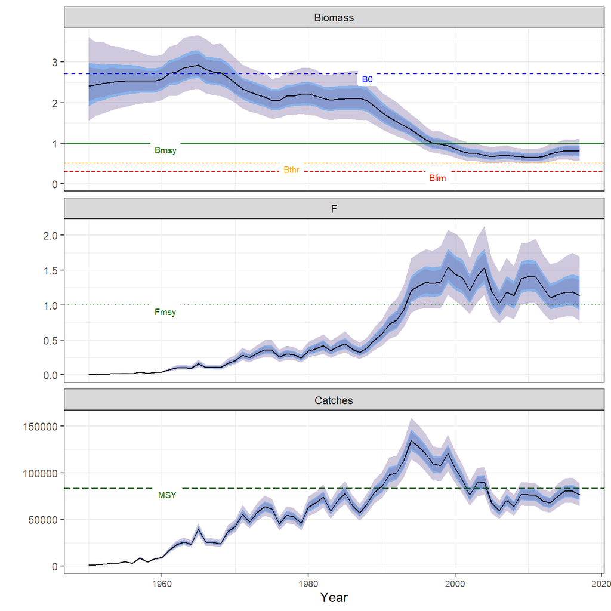

```r
FLRef::plotAdvice(stk, type = "spm") + ggplot2::facet_wrap(~qname, ncol = 1, scales = "free_y")
```

Absolute biomass and harvest rate with `rel = FALSE`:

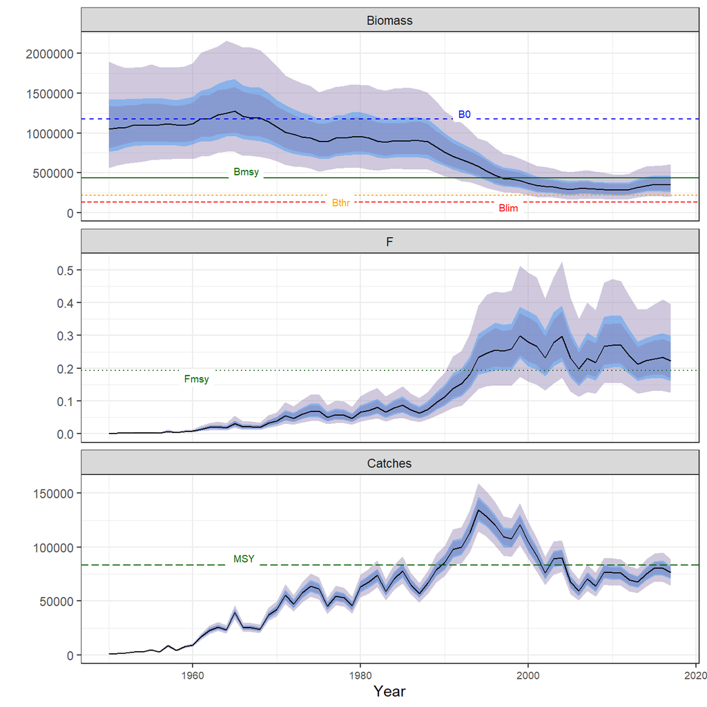

```r
FLRef::plotAdvice(jb3_FLStockR(fit, rel = FALSE, ndraws = 500), type = "spm") +
  ggplot2::facet_wrap(~qname, ncol = 1, scales = "free_y")
```

# 22 Converting from JABBA and SPiCT

## 22.1 JABBA: `jbinput2jabba3()`

`jbinput2jabba3()` takes the object returned by `JABBA::build_jabba()` and returns `list(data, priors, model)` for `jabba3()`. It carries over the priors (r, K, psi to `bkinit`, shape, catchability, status priors), the production lag, catch error, catchability and variance groups, `proc.dev.all`, the BioProcDyn process-error options and the Selex curves, and reports each difference:

- JABBA’s inverse-gamma prior on the process variance is replaced by the FishLife prior (`keep.igamma = TRUE` keeps it);
- q gets a flat prior on log q (`q.uniform = TRUE` reproduces the JAGS uniform prior on q);
- auxiliary data are not yet supported and are dropped.

```r
jb <- JABBA::build_jabba(catch = bet$catch, cpue = bet$cpue, se = bet$se, model.type = "Fox",
                         r.prior = c(0.2, 0.5), psi.prior = c(0.9, 0.25), verbose = FALSE)
options(scipen = 0)          # build_jabba() sets options(scipen = 999)
x  <- jbinput2jabba3(jb)
f2 <- jabba3(x$data, x$priors, x$model, osa = FALSE)
signif(f2$pars[c("K", "r", "sdb"), c("est", "lci", "uci")], 4)
```

```
#>           est       lci       uci
#> K   1.175e+06 6.887e+05 2.004e+06
#> r   1.929e-01 1.068e-01 3.486e-01
#> sdb 9.452e-02 6.314e-02 1.415e-01
```

> With the same process-error prior, the conversion reproduces the JABBA (RTMB engine) fit of bigeye exactly (K = 1,174,749; $B/B_{MSY}$ = 0.797 in 2017).

## 22.2 SPiCT: `spictinp2jabba3()`

`spictinp2jabba3()` takes a SPiCT input list (`inp`, as passed to `spict::fit.spict()`). JABBA3 is an annual model: catches are summed by calendar year and several index observations in a year are averaged (geometric mean). The model years span the catch and the indices, as in SPiCT; the catch in index years without catch is estimated with the hybrid F random walk (see the thornback ray chapter). SPiCT’s observation-error form is used (`obs.error = "spict"`): the observation SD is `sdi[index] * stdevfacI`, and the catch SD `sdc * stdevfacC`. The priors `logr`, `logK`, `logbkfrac`, `logsdb`, `logn`, `logsdi` (one prior per index when given by index) and `logsdf` carry over with their on/off switches, and a fixed `n` (phase -1) fixes the shape. The `alpha` and `beta` priors (ratios of observation to process SDs) and the F process in years with catch have no JABBA3 equivalent and are reported as dropped. The thornback ray chapter converts a full ICES benchmark assessment.

A SPiCT-style input list built from the bigeye data:

```r
ok1 <- is.finite(bet$cpue[, 2]); ok2 <- is.finite(bet$cpue[, 3])
inp <- list(obsC = bet$catch[, 2], timeC = bet$catch[, 1],
            obsI = list(bet$cpue[ok1, 2], bet$cpue[ok2, 3]),
            timeI = list(bet$cpue[ok1, 1] + 0.5, bet$cpue[ok2, 1] + 0.5),
            priors = list(logr = c(log(0.2), 0.5, 1), logn = c(log(2), 2, 0), logbkfrac = c(log(0.8), 0.5, 1)),
            ini = list(logn = log(2)), phases = list(logn = -1))
xs <- spictinp2jabba3(inp, stock = "bet")
fs <- jabba3(xs$data, xs$priors, xs$model, osa = FALSE)
signif(fs$pars[c("K", "r", "sdb"), c("est", "lci", "uci")], 4)
```

```
#>           est       lci       uci
#> K   1.566e+06 7.260e+05 3.377e+06
#> r   2.352e-01 1.028e-01 5.382e-01
#> sdb 1.292e-01 1.049e-01 1.593e-01
```

With the spict package installed, its example data convert the same way:

```r
data(pol, package = "spict")
xp <- spictinp2jabba3(pol$albacore, stock = "albacore")
fp <- jabba3(xp$data, xp$priors, xp$model)
fp
```

```
#> JABBA3 fit: albacore ( albacore )  engine: rtmb
#>   model: schaefer
#>   convergence: ok (max gradient 3.4e-07, Newton decrement 6.4e-15)
#>   estimates (mode, 95% CI):
#>             est      lci     uci
#> K      316.0000 168.0000 595.000
#> r        0.2480   0.1070   0.574
#> bkinit   1.2000   0.8580   1.680
#> sdb      0.1180   0.0711   0.195
#> q1       0.1740   0.0882   0.345
#> sdi1     0.0921   0.0501   0.169
#> m        2.0000       NA      NA
#> Bmsy   158.0000  83.8000 298.000
#> Fmsy     0.1240   0.0537   0.287
#> MSY     19.6000  11.9000  32.200
#>   status 1989: B/Bmsy 0.79 (0.62-0.99), F/Fmsy 1.64 (0.91-2.97)
```

# 23 Model equations

**Process equation.** Biomass relative to K, $P_t = B_t/K$, with process error acting after the catch (Winker et al. 2018) and a production lag $L$:

$$\log P_t = \log\left[P_{t-1} + \frac{r}{m-1} P_{t-1-L}\left(1 - P_{t-1-L}^{\,m-1}\right) - \frac{C_{t-1}}{K}\right] + d_t ,$$

where $m$ is the Pella-Tomlinson shape ($m = 2$ Schaefer, $m \to 1$ Fox) and $P_1$ = `bkinit`. Years before the start use the initial depletion for the lagged term.

**Process deviations.** Stationary AR(1), with $\sigma_t$ the marginal SD:

$$d_1 \sim N(0, \sigma_1^2), \qquad d_t \sim N\left(\rho\, d_{t-1},\ \sigma_t^2 (1-\rho^2)\right),$$

$\rho = 0$ giving the independent process error of JABBA and SPiCT. Either $\sigma_t = \sigma_{MSY}$ (constant) or $\sigma_t = \sigma_{MSY} x_t^{-k}$ with $x_t = B_t/B_{MSY}$ bounded to `xlim` (dynamic).

**Reference points.**

$$\frac{B_{MSY}}{K} = m^{-1/(m-1)}, \qquad F_{MSY} = \frac{r}{m}, \qquad MSY = F_{MSY} B_{MSY}.$$

**Observations.** Index $i$ in year $t$:

$$\log I_{i,t} = \log q_i + \log(K P_t) + \varepsilon_{i,t}, \qquad
\varepsilon_{i,t} \sim N\left(0,\ se_{i,t}^2 + sdi_i^2\right)$$

(`obs.error = "additive"`), or $\varepsilon_{i,t} \sim N(0, (sdi_i\,w_{i,t})^2)$ (`obs.error = "spict"`). Catch: $\log C^{obs}_t \sim N(\log C_t, sdc^2)$ when `catch.error = TRUE`.

**Estimation.** The states $\log P_t$ and catch deviations are random effects, integrated by the Laplace approximation (`engine = "rtmb"`) or sampled with the fixed effects (`engine = "nuts"`).

# 24 Summary of checks and functions

| # | Check | Red flag | Action |
| --- | --- | --- | --- |
| 1 | data (`jbplot_data`) | no contrast; conflicting indices | r prior, status priors; separate `sdi`; sensitivity runs |
| 2 | prior and posterior (`jbplot_priorpost`) | posterior = prior; posterior at the edge | report; revisit priors |
| 3 | convergence (`jb3_convergence`) | gradient, Hessian, Newton decrement | restarts; priors on r or K; fewer groups |
| 4 | residuals (`jbplot_residuals`, `jbplot_runs`, `jb3_diags`) | trends, failed runs or Ljung-Box tests | lag + AR(1); index conflict |
| 5 | retrospective (`jb3_retro`) | Mohn’s rho beyond -0.15 to 0.20 | recent data, q |
| 6 | hindcast (`jb3_hindcast`) | MASE > 1 | index without prediction skill |
| 7 | process deviations (`jbplot_procdev`) | long runs of one sign | `rho = 0.75`, `lag = amat` |
| 8 | NUTS (`jb3_nuts_diags`, `jbplot_nuts`) | $\hat{R} > 1.01$, low ESS, divergences, E-BFMI < 0.3 | longer chains; `adapt_delta`; priors |

| Topic | Recommendation |
| --- | --- |
| Process error | lag at the age at maturity + AR(1) with $\rho = 0.75$ (sensitivity 0.5, 0.9); FishLife prior on $\sigma_{MSY}$ |
| Shape | Pella with $B_{MSY}/K = 0.4$ unless known; convert the r prior with the shape |
| Engine | posterior mode for exploration, diagnostics, retro and hindcast; NUTS for final runs, and for catch-only and prior predictive runs |
| Data-limited | start with the prior predictive run (`prior.only = TRUE`); add status priors or auxiliary data and report how far each moves status |
| Simulation testing and MSE | `se = FALSE, osa = FALSE` |

## 24.1 Function reference

[output not shown]

*Planned: multi-fleet Selex, auxiliary-data lags (JABBA `auxiliary.lag`), a worked simulation-testing example.*

# 25 References

Betancourt, M. (2018). Calibrating model-based inferences and decisions. arXiv:1803.08393. https://arxiv.org/abs/1803.08393

Carvalho, F., Winker, H., Courtney, D., Kapur, M., Kell, L., Cardinale, M., Schirripa, M., Kitakado, T., Yemane, D., Piner, K.R., Maunder, M.N., Taylor, I., Wetzel, C.R., Doering, K., Johnson, K.F. and Methot, R.D. (2021). A cookbook for using model diagnostics in integrated stock assessments. *Fisheries Research* 240: 105959.

Conn, P.B. (2010). Hierarchical analysis of multiple noisy abundance indices. *Canadian Journal of Fisheries and Aquatic Sciences*, 67, 108-120. doi:10.1139/F09-175

Francis, R.I.C.C. (2011). Data weighting in statistical fisheries stock assessment models. *Canadian Journal of Fisheries and Aquatic Sciences*, 68, 1124-1138.

Hoyle, S.D., Huang, J.H.-W., Kim, D.N., Lee, M.K., Matsumoto, T. and Walter, J. (2019). Collaborative study of bigeye tuna CPUE from multiple Atlantic Ocean longline fleets in 2018. *Collective Volume of Scientific Papers ICCAT* 75(7): 2033-2080 (SCRS/2018/058).

ICCAT (2018). Report of the 2018 ICCAT bigeye tuna stock assessment meeting. International Commission for the Conservation of Atlantic Tunas, Madrid. https://www.iccat.int/Documents/Meetings/Docs/2018/REPORTS/2018_BET_SA_ENG.pdf

ICES (2023). Benchmark workshop on selected elasmobranch stocks (WKBELASMO). *ICES Scientific Reports* 5:45. 117 pp. doi:10.17895/ices.pub.22760042

Kell, L.T., Cardinale, M., Mosqueira, I., Winker, H. and Sharma, R. (2025). Transforming data and capacity-limited stock assessment: achieving risk equivalence with hierarchical assessment frameworks and auxiliary data. *Sustainability* 17: 9383. doi:10.3390/su17219383

Kell, L.T., Mosqueira, I., Grosjean, P., Fromentin, J.-M., Garcia, D., Hillary, R., Jardim, E., Mardle, S., Pastoors, M.A., Poos, J.J., Scott, F. and Scott, R.D. (2007). FLR: an open-source framework for the evaluation and development of management strategies. *ICES Journal of Marine Science* 64(4): 640-646.

Kell, L.T., Sharma, R., Kitakado, T., Winker, H., Mosqueira, I., Cardinale, M. and Fu, D. (2021). Validation of stock assessment methods: is it me or my model talking? *ICES Journal of Marine Science* 78(6): 2244-2255.

Kristensen, K., Nielsen, A., Berg, C.W., Skaug, H. and Bell, B.M. (2016). TMB: automatic differentiation and Laplace approximation. *Journal of Statistical Software* 70(5): 1-21.

Monnahan, C.C. and Kristensen, K. (2018). No-U-turn sampling for fast Bayesian inference in ADMB and TMB: introducing the adnuts and tmbstan R packages. *PLoS ONE* 13(5): e0197954.

Pedersen, M.W. and Berg, C.W. (2017). A stochastic surplus production model in continuous time. *Fish and Fisheries* 18(2): 226-243.

Schad, D.J., Betancourt, M. and Vasishth, S. (2021). Toward a principled Bayesian workflow in cognitive science. *Psychological Methods*, 26, 103-126. Preprint: https://arxiv.org/abs/1904.12765

SEDAR (2024). SEDAR 77 Stock Assessment Report: HMS Hammerhead Sharks. SEDAR, North Charleston, SC. https://sedarweb.org/documents/sedar-77-hms-hammerhead-sharks-final-stock-assessment-report/

Sherley, R.B. et al. (2020). *Ecology and Evolution* (JARA census model applied to absolute abundance indices). doi:10.1002/ece3.6554

Thorson, J.T. (2020). Predicting recruitment density dependence and intrinsic growth rate for all fishes worldwide using a data-integrated life-history model. *Fish and Fisheries* 21(2): 237-251.

Thorson, J.T., Shelton, A.O., Ward, E.J. and Skaug, H.J. (2015). Geostatistical delta-generalized linear mixed models improve precision for estimated abundance indices for West Coast groundfishes. *ICES Journal of Marine Science*, 72, 1297-1310.

Thygesen, U.H., Albertsen, C.M., Berg, C.W., Kristensen, K. and Nielsen, A. (2017). Validation of ecological state space models using the Laplace approximation. *Environmental and Ecological Statistics* 24(2): 317-339.

Vehtari, A., Gelman, A., Simpson, D., Carpenter, B. and Bürkner, P.-C. (2021). Rank-normalization, folding, and localization: an improved $\hat{R}$ for assessing convergence of MCMC. *Bayesian Analysis* 16(2): 667-718.

Winker, H. et al. (2026). Process error in surplus production models: scale, persistence and inflation (BioProcDyn). In preparation.

Winker, H., Carvalho, F. and Kapur, M. (2018). JABBA: Just Another Bayesian Biomass Assessment. *Fisheries Research* 204: 275-288.

Winker, H., Carvalho, F., Thorson, J.T., Kell, L.T., Parker, D., Kapur, M., Sharma, R., Booth, A.J. and Kerwath, S.E. (2020). JABBA-Select: incorporating life history and fisheries’ selectivity into surplus production models. *Fisheries Research* 222: 105355.

Winker, H., Thorson, J.T., Fairweather, T., Leslie, R. and Durholtz, D. (2017). Towards improving precision in South African demersal trawl survey indices using geostatistical GLMMs. MARAM/IWS/2017/Hake/BG8. University of Cape Town.